# Assignment_10287773

10287773

24/02/2022

# Question 1

Question 1 pertains to an experiment that had 24 participants and had a repeated measure experimental design. The dependent variable for this experiment was response time measured in milliseconds (M/S). The independent variable for this study was the context in which an item was displayed. Context had three levels: “Neutral”, “Negative”, and “Positive”. There were 24 items which were shown in each of the three contexts. Overall, this equated to 574 trials. This markdown takes the raw data refines, explores, and visualises it before building the appropriate Mixed Model to determine whether the context an item was shown in influenced response times.

**Load Packages**

First the relevant packages are loaded. Note the packages are loaded in the order they are first used. The {tidyverse} package is loaded as it encompasses several packages useful for data wrangling and visualisation. For example, the {dplyr} package within the {tidyverse} provides multiple functions such as summarise, mutate and rename which are used widely in this markdown for data wrangling. {tidyverse} also includes {ggplot2} which is the principal package used in this markdown for data visualisation. Although there are many visualisation packages in R {ggplot2} is chosen given the packages superior customisability and simple syntax. The {table1} package is loaded as it facilitates the creation of simple yet aesthetically pleasing summary statistic tables. This package also provides more flexibility in display than others and produces the tables in the appropriate html format. The {ggdark} package is a thematic add on library that can be used in conjunction with {ggplot2}. Specifically, the package has several dark background themes that provide a distinct contrast to the data points which improves the visualisations overall clarity. The {lme4} and {lmerTest} packages are used together. {lme4} is a package that allows the building of fit linear and generalized linear mixed-effects models. This will be needed to answer the current question. The {lmerTest} package allows the generation of pvalues that are strapped on to the output of the models built with the {lme4} package. The {performance} package provides computing measures that can be interpreted to assess the quality of the model built. These measures are outside those provided in base R. Finally, the {emmeans} package is loaded as it facilitates post hoc testing of mixed models. Of particularly interest is the {emmeans} packages ability to make pairwise comparisons and calculate estimated marginal means. Finally, the {sjPlot} package is loaded. This package creates Html summary tables for regression models which will be used in the final write up of the answers to each question.

```r
library(tidyverse)
library(table1)
library(ggdark)
library(lme4)
library(lmerTest)
library(performance)
library(emmeans)
library(sjPlot)
```

**Read in the Data**

The raw data is read in and saved under an appropriate title.

```r
assignment_data <- read.csv("assignment1_data1.csv")
```

### Data Wrangling

**Snapshot of the Data**

The {head} function is used to get a brief snapshot of the data frame. On observation of the output there are three problems that need rectifying before going further in the exploration of this data.

1. Appropriately rename the headers
2. Remove part of the string for each element in both the Subject and Item column.
3. Mutate the data type of the variables Subject, Item and Condition to a factor.

```r
head(assignment_data)
```

```
##   subj item   DV condition
## 1   S1   I1  867   Neutral
## 2   S1   I2 1111  Positive
## 3   S1   I3  771  Negative
## 4   S1   I4  626   Neutral
## 5   S1   I5 1333  Positive
## 6   S1   I6  846  Negative
```

**Problem 1 - Rename column labels**

The first problem is the current headers need renaming. This is important for two reasons. Firstly, in this case of this data some of the current variable names do not clearly indicate what they refer to. Obviously, for someone just looking at the code without prior knowledge this is problematic and needs to be rectified for clarity. Secondly, the current data frame does not have consistency in capitalisation which limits the overall tidiness of the data.

To do this the {rename} function has been applied. After applying the function, I first indicate the data set I wish to edit. Next, I indicate that I want to change column names with the c. Inside the brackets the desired name is entered followed by an equal’s sign and then the variable I wish to change the name of. I have capitalised all the headers to gain the consistency that improves the overall tidiness of the data. I have also given each variable a ‘full’ name and changed the name DV to RT to signify the column pertains to reaction times. As a final note I have saved these changes onto a new data frame called tidied_data. This is so the raw data remains unedited.

```r
tidied_data <- rename(assignment_data, c(Subject = subj,
                                             Item = item,
                                             RT = DV,
                                             Condition = condition))
```

**Problem 2 - Remove specific strings from elements within the data**

The second problem is that in both the columns pertaining to Item and Subject the elements have an added string that is not needed e.g the S before the subject ID and the I before the item ID. Although not terminal to the analysis it is unnecessary and makes the data set untidier. As a result, I have opted to remove these strings.

To do this in the {tidyverse} style I have applied the {mutate_at} function. {mutate_at} specifically makes changes in the way designated by the parameters set inside the brackets. First the column the changes are made at is identified. Then the {str_replace} function is applied. This function replaces all occurrences of the search string with the replacement string. The search string is the letters inside the first set of quotation marks after the {str_replace} function. In the case of the code below that is I for the item column and S for the subject column. The aim here is to delete the search string instead of replacing it so in the second set of speech marks no characters are entered. This means when applied the search string is deleted but no new elements are added.

```r
tidied_data <- tidied_data %>%
  mutate_at("Item", str_replace, "I", "") %>%
  mutate_at("Subject", str_replace, "S", "")
```

**Problem 3 - Mutate relevant variables to factors**

The final problem that needs fixing in this data frame is that some variables that need to be viewed in R as factors are currently seen as other data types. Although not necessarily problematic in the data visualisation phase it will become a problem further into the exploration of the data and as such needs to be fixed.

```r
tidied_data <- tidied_data %>%
  mutate(Subject = factor(Subject),
         Item = factor(Item),
         Condition = factor(Condition))
```

**Wrangled data**

The data has now been completely wrangled and is ready for visualisation and further analysis. The {head} function is applied below to give a reference of the cleaned data frame.

```r
head(tidied_data)
```

```
##   Subject Item   RT Condition
## 1       1    1  867   Neutral
## 2       1    2 1111  Positive
## 3       1    3  771  Negative
## 4       1    4  626   Neutral
## 5       1    5 1333  Positive
## 6       1    6  846  Negative
```

### Data Exploration

**Descriptive statistics**

Descriptive statistics are generated to provide a brief summarisation of the data. To generate the descriptive statistics the {table1} function has been applied from the {table1} package. The {table1} package allows the production of html tables that include mean, standard deviation, median and minimum/maximum values. The {table1} package has the additional advantage of its default formatting style being APA which is a very clear format.

To create this table two actions were taken. First as the response time variable is defined as RT in the data it needed relabelling for clarity. Continuing with {tidyverse} style the {label} function was first applied. The {label} function identifies and retrieves the attributes of the designated label. To select the relevant label the data frame is stated and then the column within the df conjoined by a $ symbol. Finally, the new label name is denoted within the speech marks.

Now the labels are correct the table can be generated. To do this the {table1} function is called. This function will create descriptive statistics and format the table. The characteristics of the table are defined inside the brackets. First the variable that will be used to generate the statistics is stated which in this case is RT. Then the | symbol is employed to denote the next variable is the grouping variable which in this case is condition. Next the data frame from this table is stated. Finally, the overall column that is generated by default using {table1} is removed. In this case there is no theoretical sense in having such a column so its addition would have been unclear. To do this {overall=F} is applied. Overall denotes the overall column and = F essentially means do not generate.

```r
label(tidied_data$RT)<-"Response Time"
table1(~RT| Condition, data = tidied_data, overall=F)
```

|  | Negative (N=191) | Neutral (N=191) | Positive (N=192) |
| --- | --- | --- | --- |
| Response Time |  |  |  |
| Mean (SD) | 1090 (565) | 1190 (562) | 1260 (553) |
| Median [Min, Max] | 957 [314, 4610] | 1070 [298, 3560] | 1210 [361, 5240] |

**Data Visualisation**

The aim of this visualisation is to represent the data in a way that allows inferences regarding whether the context a word is displayed in effects response times. To do this a violin plot has been created that chart’s reaction times for each of the three word context conditions. In this plot each data point is coloured based on the word context condition it came from. Below I have outlined the plot layer by layer.

First the {set.seed} function is applied to identify the starting number used to generate a sequence of random numbers. The purpose of this is that given the seed number remains the same the output will always be the same and thus reproducible.

The {ggplot} function from the {tidyverse} package used with the {aes} function indicate the basic parameters of the plot that will remain consistent through the subsequent layers. Our IV Word context condition is selected along the x axis using the x = syntax. Similarly, the DV reaction time is charted along the y axis using y =. Next using the {colour} function the data points are coloured based on the word context condition they come from. The {geom_violin} function is used to set the graph type to violin. This is the most effective graph to display both the data by condition as well as the distribution of these data points. In the next layer the {stat_summary} function is applied. This function represents the summary functions applied within the brackets graphically. Within the brackets I have set “mean_cl_boot” which creates a graphical representation of the mean for each condition as well as adding confidence interval. Then the colour parameters have been set as white so that the resulting part of the graph stands out. In the next layer the {geom_jitter} function is applied to slightly stagger the data points off the line so they are more visible. Specifically, a jitter width of 0.1 was applied using the width = syntax to provide the most clarity. Alongside this an alpha of .15 was chosen. This relates to the opaqueness of each data point. This choice is actually predicated on the order in which the layers have been set. I chose to drop the mean point behind the data points as I think it provided more clarity. However, an alpha level that made the points opaquer made the mean difficult to see so the points have been made more translucent which I believe has created the clearest graph. The graph is clear and as a result there is not a need for a further legend. To remove the default legend the guides function is applied followed by the colour parameter ‘none’. This removes the legend from the graph. Next the {labs} function was applied to alter the labels on the graph. To do this within the {labs} bracket the relevant label was first identified then the equals sign was applied followed by the renamed label. When reviewing the plot, I felt a black background theme provided the best contrast, so I applied the {dark_theme_light} function to create a dark mode aesthetic for my plot. This function is part of the {ggdark} package. Finally, the {coord_flip} function was applied to flip the axis. This created an aesthetically pleasing and clear effect which allows viewers to easily make inferences about the data.

```
## Inverted geom defaults of fill and color/colour.
## To change them back, use invert_geom_defaults().
```

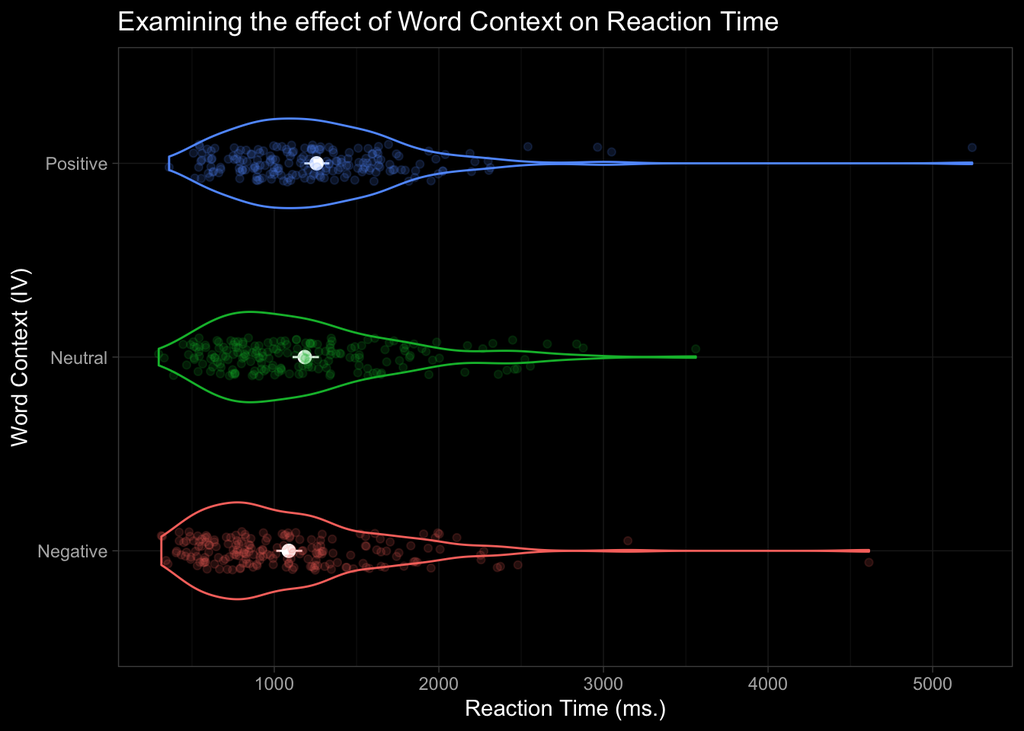

```r
set.seed(1234)
tidied_data %>%
  ggplot(aes(x = Condition, y = RT, colour = Condition)) +
  geom_violin(width = .5) +
  stat_summary(fun.data = "mean_cl_boot", colour = "white") +
  geom_jitter(width = .1, alpha = .15) +
  guides(colour = "none") +
  labs(x = "Word Context (IV)",
       y = "Reaction Time (ms.)",
       title = "Examining the effect of Word Context on Reaction Time ") +
  dark_theme_light() +
  coord_flip()
```

### Data Analysis

**Build Model**

Before beginning the model development, it must be made explicitly clear there is no singularly correct Mixed Model that determines whether the fixed effect of condition influenced response times. Many different models can be created all with different levels of usefulness. In the words of statistician George Box “all models are wrong, but some are useful.”

The first model built is the most complex model that models the fixed effect, random effects as well as the random slopes between Items and Subjects using the {lmer} function. The syntax is as follows. First after applying the {lmer} function the DV is identified which for the current model is RT. Next after applying the ~ symbol the fixed effect is identified which is condition. The fixed effect is our experimental manipulation. The random effect terms are then added inside each set of brackets. Random effects are factors that have many possible levels all of interest, yet a given data frame only has a random set of these levels. In this case the random effects are Subject and Item. Random slopes can be applied to address the problematic assumption that the magnitude of effect between levels of a variable are consistent. To do this in the current data frame the syntax of the random slope is 1 + Condition followed by the random effect variable

So overall the syntax for this model can be summarised as RT is predicted by the fixed effect of condition plus the random effects (including the random sloped) of Subject and Item.

```r
model_1 <- lmer(RT ~ Condition + (1 + Condition | Subject)
                + (1 + Condition | Item), data =tidied_data)
```

```
## boundary (singular) fit: see help('isSingular')
```

Unfortunately as shown above a warning model is displayed when this model is run. Simply this warning indicates this model is too complex for the richness of the data set.

**Second Model**

To remove this warning the parameters of the random effects must be simplified to match the richness of the data. To simplify the random effect parameters the random slopes within each of the random effects can be removed. model_2 in comparison to the previous model is the same except the fixed effect has been removed from within the random effect parameters. This model now runs without the warning appearing.

```r
model_2 <- lmer(RT ~ Condition + (1 | Subject)
                + (1 | Item), data = tidied_data)
```

**Check Model Assumptions**

Now that an appropriate model has been built it must be checked to see whether it meets the assumptions of a mixed model. To do this the {check_model} function can be applied from the {preformance} package. This function provides a visual check of the various assumptions of the model.

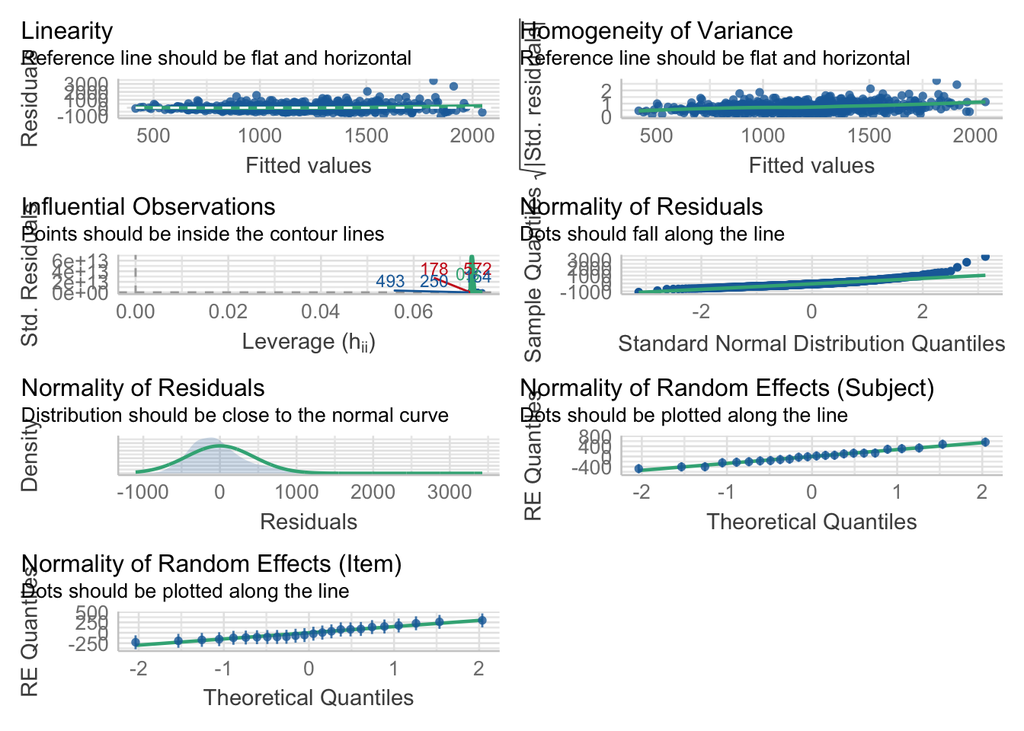

```r
check_model(model_2)
```

The output of this model indicates no serious breach of the assumptions and as such the model can be used in analysis.

**Likelihood Ratio Test**

Before gaining a summary of the model it must pass one final test known as likelihood ratio test (LRT). Essentially, LRT is used to determine whether the model built that includes the fixed effect is better at capturing the data than a null model that does not include a fixed effect.

To do this first a null model was constructed. This model is identical to the previous model except the fixed effect has been removed. The syntax of the null model can be summarised as RT is predicted by the random effects of Subject and Item. The model must be as identical as possible as LRTs can only be carried out on nested models.

```r
model_null <- lmer(RT ~ (1 | Subject) + (1 | Item),
                   data = tidied_data)
```

```r
anova(model_2, model_null)
```

```
## refitting model(s) with ML (instead of REML)
```

```
## Data: tidied_data
## Models:
## model_null: RT ~ (1 | Subject) + (1 | Item)
## model_2: RT ~ Condition + (1 | Subject) + (1 | Item)
##            npar    AIC    BIC  logLik deviance  Chisq Df Pr(>Chisq)
## model_null    4 8763.7 8781.1 -4377.8   8755.7
## model_2       6 8754.2 8780.3 -4371.1   8742.2 13.473  2   0.001187 **
## ---
## Signif. codes:  0 '***' 0.001 '**' 0.01 '*' 0.05 '.' 0.1 ' ' 1
```

There are multiple measures in the output summary that can be used to determine which model is better. The first two measures to consider are AIC and BIC. Both measures produce values that denote the amount of information not explained by our model. For these measures lower values indicate a better model. The deviance measure can also be considered. This measure compares the deviant sums of squares in each model. Similarly, to AIC and BIC lower values indicate a better model.

In the case of the current comparison on all three measures the fixed effect model scores better. The fixed effect model has an AIC value of 8754.2 compared to 8763.7 in the null model. Similarly the fixed effect model has a BIC value of 8780.3 compared to 8781.1 in the null model. Finally the deviance value for the fixed effect model was 8742.2 compared to 8755.7 for the null model. As a result, it can be concluded the fixed effect model built is a better model for capturing the data than the null model.

### Results

**Summary of model**

A summary can now be gained by applying the {summary} function followed by the model name. The output shows information on both the fixed effects and random effects. The focus from an experimental standpoint is on the output regarding fixed effects. As a note the intercept refers to the negative condition due to the default dummy coding.

```r
summary(model_2)
```

```
## Linear mixed model fit by REML. t-tests use Satterthwaite's method [
## lmerModLmerTest]
## Formula: RT ~ Condition + (1 | Subject) + (1 | Item)
##    Data: tidied_data
##
## REML criterion at convergence: 8713.1
##
## Scaled residuals:
##     Min      1Q  Median      3Q     Max
## -2.4202 -0.6259 -0.1500  0.4040  7.5278
##
## Random effects:
##  Groups   Name        Variance Std.Dev.
##  Subject  (Intercept)  80886   284.4
##  Item     (Intercept)  29611   172.1
##  Residual             206878   454.8
## Number of obs: 574, groups:  Subject, 24; Item, 24
##
## Fixed effects:
##                   Estimate Std. Error      df t value Pr(>|t|)
## (Intercept)        1086.50      75.42   45.21  14.407  < 2e-16 ***
## ConditionNeutral     98.28      46.55  525.13   2.111 0.035234 *
## ConditionPositive   170.80      46.49  525.09   3.674 0.000263 ***
## ---
## Signif. codes:  0 '***' 0.001 '**' 0.01 '*' 0.05 '.' 0.1 ' ' 1
##
## Correlation of Fixed Effects:
##             (Intr) CndtnN
## ConditnNtrl -0.309
## ConditnPstv -0.309  0.501
```

The results show the average reaction time for each condition: Negative = 1086.50 ms, Neutral = 1184.78 ms and Positive = 1257.30 ms. The summary also does T-tests for each condition against the Intercept. According to these T-tests both the Neutral and Positive condition significantly differ in response time in comparison to the Negative condition, however, multiple problems exist. First multiple comparisons are being made without adjusting for the family wise error rate which increases the chance of making type 1 errors. The second problem is that comparisons are only made that include the Negative condition so other theoretically important comparisons have not been made e.g Neutral compared to Positive.

**Check with emmeans**

To assess the model further and account for the two problems raised in relation to the previous summary the {emmeans} function from the {emmeans} package can be applied. The {emmeans} function allows further post hoc testing of mixed models. Specifically, the function makes pairwise comparisons and calculates estimated marginal means. Syntactically to produce an {emmeans} summary the function is applied followed by the model and then the variable on which pairwise comparisons will be done.

```r
emmeans(model_2, pairwise ~ Condition)
```

```
## $emmeans
##  Condition emmean   SE   df lower.CL upper.CL
##  Negative    1087 75.4 45.2      935     1238
##  Neutral     1185 75.4 45.2     1033     1337
##  Positive    1257 75.4 45.1     1106     1409
##
## Degrees-of-freedom method: kenward-roger
## Confidence level used: 0.95
##
## $contrasts
##  contrast            estimate   SE  df t.ratio p.value
##  Negative - Neutral     -98.3 46.6 525  -2.111  0.0885
##  Negative - Positive   -170.8 46.5 525  -3.674  0.0008
##  Neutral - Positive     -72.5 46.5 525  -1.560  0.2640
##
## Degrees-of-freedom method: kenward-roger
## P value adjustment: tukey method for comparing a family of 3 estimates
```

The {emmeans} summary produces estimated marginal means almost exactly the same as the estimates displayed through the {summary} function. However, in contrast to the {summary} output the {emmeans} output summary shows that of the three pairwise comparisons made only one comparison produces a significant difference in response times. This is likely due to the p-value adjustments made using the Tukey method to account for the family wise error rate.

**Answer to question**

The analyses carried out using the {lme4} package (Bates, Maechler, Bolker, & Walker, 2015) to fit the linear mixed models for the response time measure in R version 1.3.1093 (R Development Core Team, 2020). Pairwise comparisons conducted with the {emmeans} package (Lenth, 2018) were used to investigate the effect of the context a word was shown in on the Response Time measure. Below is a report of the regression using the {tab_model} function.

```r
tab_model(model_2, show.std = TRUE)
```

|  | Response Time |  |  |  |  |
| --- | --- | --- | --- | --- | --- |
| Predictors | Estimates | std. Beta | CI | standardized CI | p |
| (Intercept) | 1086.50 | -0.16 | 938.38 – 1234.63 | -0.42 – 0.10 | **<0.001** |
| Condition [Neutral] | 98.28 | 0.17 | 6.84 – 189.71 | 0.01 – 0.34 | **0.035** |
| Condition [Positive] | 170.80 | 0.30 | 79.50 – 262.11 | 0.14 – 0.47 | **<0.001** |
| Random Effects |  |  |  |  |  |
| σ<sup>2</sup> | 206878.31 |  |  |  |  |
| τ<sub>00</sub> <sub>Subject</sub> | 80885.93 |  |  |  |  |
| τ<sub>00</sub> <sub>Item</sub> | 29611.17 |  |  |  |  |
| ICC | 0.35 |  |  |  |  |
| N <sub>Subject</sub> | 24 |  |  |  |  |
| N <sub>Item</sub> | 24 |  |  |  |  |
| Observations | 574 |  |  |  |  |
| Marginal R<sup>2</sup> / Conditional R<sup>2</sup> | 0.015 / 0.358 |  |  |  |  |

The question to be answered is whether the context a word was shown in influences response times. Considering the results of the {emmeans} analysis it can be concluded response times to words shown in a Negative context compared to a Positive context differed significantly (t = -3.674, p < .001). This effect is quantified as an estimated mean difference in response time of -170.8(ms) when comparing the Negative context to the Positive context. Statistically significant effects were not found when comparing Negative to Neutral contexts (p > 0.05) and Neutral to Positive contexts (p > 0.05).

# Question 2

Question 2 pertain to an experiment that had 32 participants and had a 2 x 2 factorial repeated measure experimental design. The dependent variable for this experiment was response time measured in milliseconds (M/S). This experiment has two independent variables. Story (vignette) Emotion which had two levels: Anger or Fear and Facial Expression which also had the same two levels. This markdown takes the raw data refines, explores, and visualises it before building the appropriate Mixed Model to determine whether the fixed factors of Story Emotion and Facial Expression influenced response times.

**Read in the data**

The raw data is read in and saved under an appropriate title.

```r
factorial_data <- read.csv("assignment1_data2.csv")
```

### Data Wrangling

**Snapshot of data**

```r
head(factorial_data)
```

```
##   Subject Vignette StoryEmotion FaceExpression   RT
## 1      38       10        Anger          Anger 2896
## 2      39       10        Anger          Anger 2676
## 3      40        9        Anger          Anger 1199
## 4      42       10        Anger          Anger 2464
## 5      44        9        Anger          Anger 2010
## 6      45       10        Anger          Anger 2343
```

On observation of the output there are two problems that need rectifying before going further in the exploration of this data.

1. Appropriately rename the independent variable headers
2. Mutate the data type of the variables Subject, Vignette, Story Emotion and Facial Expression.

**Problem 1 - Rename headers**

Currently the two IVs names are without spaces creating an untidy aesthetic to an otherwise clean data frame. The aim is to create separation between the two words that make up each column header. When creating separation an underscore was used instead of a space due to the coding issues a space in a label name would create.

```r
factorial_data_tidied <- rename(factorial_data,
                                c(Story_Emotion = StoryEmotion,
                                Facial_Expression = FaceExpression))
```

**Problem 2 - Mutate relevant variables to factors**

Similarly, to the previous question again some variables that need to be viewed in R as factors are currently seen as other data types. In this case the variables in need of mutation are as follows: Subject, Vignette, Story_Emotion and Facial_Expression. To change these variables, I have applied the {mutate} function from the tidyverse package. The same syntax as last time is applied after the application of the {mutate} function. First the variable that will be changed is identified followed by an equal sign. Next the {factor} function is applied followed by the variable that we wish to change. The {factor} function changes the data type of the selected variable to a factor.

```r
factorial_data_tidied <- factorial_data_tidied %>%
  mutate(Subject = factor(Subject),
         Vignette = factor(Vignette),
         Story_Emotion = factor(Story_Emotion),
         Facial_Expression = factor(Facial_Expression))
```

### Wrangled data

The data has now been completely wrangled and is ready for visualisation and further analysis

```r
head(factorial_data_tidied)
```

```
##   Subject Vignette Story_Emotion Facial_Expression   RT
## 1      38       10         Anger             Anger 2896
## 2      39       10         Anger             Anger 2676
## 3      40        9         Anger             Anger 1199
## 4      42       10         Anger             Anger 2464
## 5      44        9         Anger             Anger 2010
## 6      45       10         Anger             Anger 2343
```

## Data Visualisation

**Descriptive Statistics**

To generate descriptive statistics, I have again opted to use the {table1} package and function. As previously noted, this package facilitates the production of html tables that include mean, standard deviation, median and minimum/maximum values. The generation of the table is similar to in the previous question except for one extra step at the beginning.

The new step is necessary as the default labelling system in the {table1} package is not tailored for factorial data. The issue is there is no functionality to add a label to our grouping variables. This is normally not an issue given an experiment may only have one grouping variable or the grouping variable levels are labelled differently so it is obvious which label pertains to what. Uniquely, this experiment has two grouping variables both with the same level labels and as such without indication of which variable they belong to the table is difficult to interpret.

The solution developed to solve this problem was as follows. {table1} displays the level names in the table so if a reference to the variable the level represent can be created then it would be shown in the table. To do this the level names for one of the variables needed to be mutated. Story_Emotion was chosen as it is the top grouping variable in the table and as such only appears once meaning there was more room (See table). The syntax to change each level was as follows. A new df called table_data was created that had the data in a format appropriate for the table. Then the df that was going to be edited was called. The pipe function was then used which can be read as ‘and then’. The {mutate_at} function was then applied which is a function that has the same function as the {mutate} function used previously except the parameters of where mutations should take place have to be set. Next the {str_replace} function was applied. This function replaces all occurrences of the search string with the replacement string. The search string was the level name indicated in the speech marks. The replacement string was the level name plus the variable it refers to in brackets. This syntax was repeated twice for each of the two levels.

```r
table_data <- factorial_data_tidied %>%
  mutate_at("Story_Emotion", str_replace, "Anger", "Anger (Story
            Emotion)") %>%
  mutate_at("Story_Emotion", str_replace, "Fear", "Fear (Story
            Emotion)")
```

Now that the level labels in the table data frame are appropriate the RT label needs renaming Response Time in the same way as last time. As previously discussed, the {label} function was first applied. Then to select the relevant label the data frame is stated and then the column within the df conjoined by a $ symbol. Finally the new label name is denoted within the speech marks.

```r
table1::label(table_data$RT)<-"Response Time"
```

The summary table can now be generated. Again, the variable that will be used to generate the statistics is stated which in this case is RT. Then the | symbol is employed to denote the next variable is the grouping variable. In this case due to the factorial design statistics are grouped by both Story Emotion and Facial Expression. To do this both names are wrote conjoined by the operator colon. Next the data frame for this table is stated. Finally, the overall column that is generated by default using {table1} is removed using the syntax overall=F.

```r
table1::table1(~RT| Story_Emotion:Facial_Expression, data = table_data, overall=F)
```

|  | Anger (Story Emotion) Anger (N=237) | Anger (Story Emotion) Fear (N=229) | Fear (Story Emotion) Anger (N=191) | Fear (Story Emotion) Fear (N=252) |
| --- | --- | --- | --- | --- |
| Response Time |  |  |  |  |
| Mean (SD) | 1850 (1080) | 2630 (2030) | 2520 (1870) | 2030 (1160) |
| Median [Min, Max] | 1480 [476, 5570] | 1850 [659, 9650] | 1820 [499, 9480] | 1680 [363, 6090] |

**Violin Plots**

The aim of this visualisation is to represent the data in a way that allows inferences regarding whether different interaction between Story context a Facial expression effects response times. To do this a set of violin plot have been created that chart’s reaction times for different set of interactions between Story Context and Facial Expression. In each plot the data points are coloured based on the interaction they represent. The plot is syntactically very similar to the previous plot and as such a briefer explanation of the plot is given below.

Again the {set.seed} function is applied to identify the starting number used to generate a sequence of random numbers.

The {ggplot} function is called, and the basic parameters of the plot are defined. The interaction between our IVs is selected along the x axis using the x = syntax. Similarly, the DV reaction time is charted along the y axis using y =. The {colour} function is used to colour the data points based on the interaction levels they represent. The {geom_violin} function is used to set the graph type to violin. In the next layer the {stat_summary} function is applied to create mean points with confidence levels. Then the colour parameters have been set as white so that the resulting part of the graph stands out. The reason for the application of the {geom_jitter} and the requisite alpha levels are the same as in Question 1. To recap the {geom_jitter} function is applied to slightly stagger the data points off the line, so they are more visible. Alongside this an alpha of .15 was chosen as it creates the best opaqueness for the data points given the order of the {ggplot} layers. The legend is then dropped using the {guides} function followed by the colour parameter ‘none’. Next the {labs} function was applied to alter the labels on the graph. When reviewing the plot, I felt a black background theme provided the best contrast, so I applied the {dark_theme_light} function to create a dark mode aesthetic for my plot. Finally, the coord_flip function was applied to flip the axis. This created an aesthetically pleasing and clear effect which allows viewers to easily make inferences about the data.

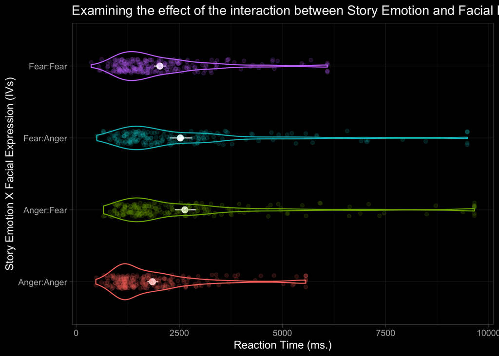

```r
set.seed(1234)
factorial_data_tidied %>%
  ggplot(aes(x = Story_Emotion:Facial_Expression,
             y = RT, colour = Story_Emotion:Facial_Expression)) +
  geom_violin(width = .5) +
  stat_summary(fun.data = "mean_cl_boot", colour = "white") +
  geom_jitter(width = .1, alpha = .15) +
  guides(colour = "none") +
  labs(x = "Story Emotion X Facial Expression (IVs)",
       y = "Reaction Time (ms.)",
       title = "Examining the effect of the interaction between Story Emotion and Facial Expression on Reaction Times ") +
  dark_theme_light() +
  coord_flip()
```

## Data Analysis

**Setting deviation coding**

Before building the correct mixed model the coding of variables must be changed to deviation coding instead of Rs’ default dummy coding. This is because dummy coding factorial design data can lead to misinterpreting simple effects. Deviation coding results in the intercept of the model corresponding to the grand mean of the conditions and makes the interpretation of the fixed effects more straightforward.

To apply deviation coding the following code is applied. First the {contrasts} function is called followed in brackets by the data frame and then the relevant variable. Finally, the {matrix} function is called, and the parameters are set within the brackets. The result of this code is the creating of a contrast matrices where the intercept of the model corresponds to the grand mean of the conditions.

```r
contrasts(factorial_data_tidied$Story_Emotion) <- matrix(c(.5, -.5))
contrasts(factorial_data_tidied$Facial_Expression) <- matrix(c(.5, -.5))
```

**Model Development**

**Model 1**

As previously discussed there is no singularly correct Mixed Model to determine whether the interaction between Story Emotion and Facial Expression influenced response times. The first model that has been built is similar to the model 1 from Question 1 due to the fact it models the fixed effect, random effects as well as the random slopes for both fixed effects.

```r
factorial_model <- lmer(RT ~ Story_Emotion * Facial_Expression +
                  (1 + Story_Emotion + Facial_Expression | Subject)+
                  (1 + Story_Emotion + Facial_Expression |Vignette),
                  data = factorial_data_tidied)
```

```
## boundary (singular) fit: see help('isSingular')
```

```
## Warning: Model failed to converge with 2 negative eigenvalues: -9.3e-03 -5.3e+01
```

The warning message produced again indicates that the model built is too complex for the richness of the data.

**2nd Model**

As a result of the warning message in the previous model the random effect terms have been dropped until the message no longer appears. Syntactically this model is the same as the previous model minus the addition of Story Emotion and Facial Expression in the random effect terms.

```r
factorial_model_2 <- lmer(RT ~ Story_Emotion * Facial_Expression +
                          (1 | Subject) +
                          (1 | Vignette),
                          data = factorial_data_tidied)
```

**Performance Check**

Now that an appropriate model has been built it must be checked to see whether it meets the assumptions of a mixed model. To do this the {check_model} function is again applied from the {preformance} package. This function provides a visual check of the various assumptions of the model.

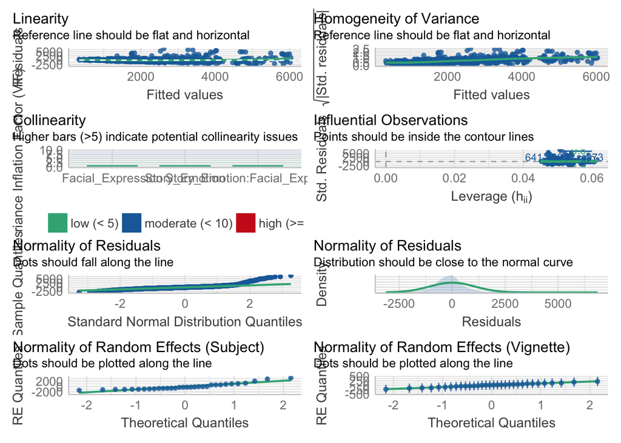

```r
check_model(factorial_model_2)
```

On observation of the models performance there is a violation of the assumption of normality of residuals. Except for this the assumptions do not seem to be violated.

**Cullen & Frey Plot**

To further explore the effect of the potential violation of assumptions for a mixed model identified in the previous code a Cullen & Frey plot is generated. This plot gives an idea of the distribution family the data falls into which is useful for understanding whether the appropriate model is being created. To create the Cullen & Frey plot the package {fitdistrplus} is loaded do the {descdist} function can be called. This function computes descriptive parameters of an empirical distribution and provides a skewness-kurtosis plot.

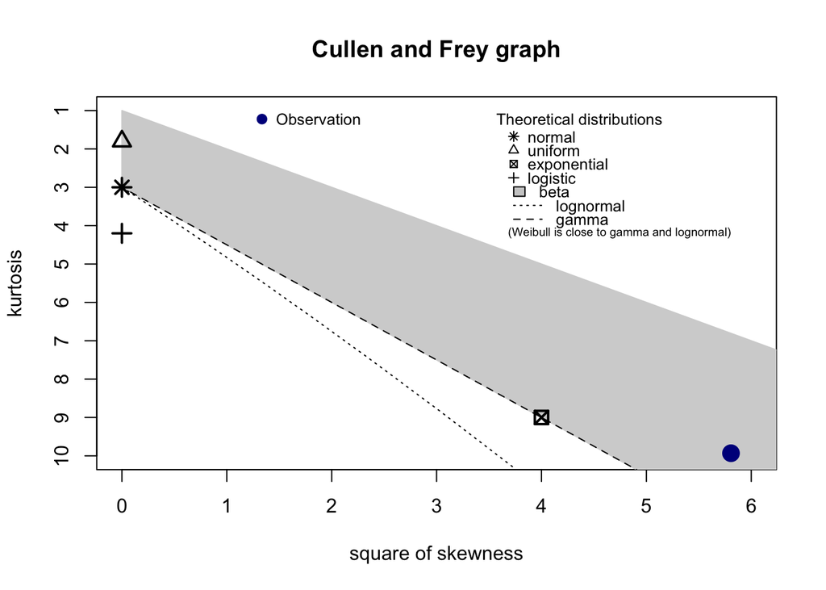

```
## summary statistics
## ------
## min:  363   max:  9652
## median:  1706
## mean:  2238.018
## estimated sd:  1595.012
## estimated skewness:  2.409722
## estimated kurtosis:  9.931861
```

```r
library(fitdistrplus)
descdist(factorial_data_tidied$RT)
```

The resulting graph shows the data is skewed considerably towards the right in terms of distribution. As a result it appears although the model created would produce somewhat correct results it may not be the most appropriate model.

**Gamma Model**

Considering the results of the previous graph a gamma model has been built. Gamma models are uniquely adapted to deal with the right sided skew observed in the data and as such may be a more appropriate graph. That being said it must be noted no model is perfect and although the gamma model will produce better results than the original mixed model it does not mean it is the perfect model.

There is an immediate problem when developing a gamma model. In the case of a gamma model the random effect slopes can only be applied for one of the two factors wothout causing a convergence error. As a result two gamma models have been developed. One that estimates the random slopes of Facial Expression and one for Story Emotion. This is a relatively small change to the model but it is important to discern whether this effects the results.

To build both gamma model the {glmer} function is called. {glmer} is a function that allows mixed models to be fitted depending on their datas distribution. Within the brackets after the {glmer} function the parameters of the previous model are applied again. However, in this case the random slopes for either story emotion or facial expression can be added without convergence errors. To do this story emotion or facial expression is added to the left side of each set of brackets conjoined to the one by the + operator. After this the distribution family is defined as gamma using the sytax family = gamma. Next the nAGQ is set to zero. nAGQ is set to zero to stop a convergence error. Although a higher value e.g 1 is more accurate the chance of a convergence error increases and as such a trade off must take place for the model to work. Finally, the data frame is indicated.

```r
gamma_model_story <- glmer(RT ~
                                 Story_Emotion * Facial_Expression +
                                 (1 + Story_Emotion | Subject) +
                                 (1 + Story_Emotion | Vignette),
                               family = Gamma,
                               nAGQ = 0,
                               data = factorial_data_tidied)

gamma_model_face <- glmer(RT ~
                                 Story_Emotion * Facial_Expression +
                                 (1 + Facial_Expression | Subject) +
                                 (1 + Facial_Expression | Vignette),
                               family = Gamma,
                               nAGQ = 0,
                               data = factorial_data_tidied)
```

**Compare to null**

Again before gaining a summary of the model it must pass the likelihood ratio test (LRT). A null model was constructed for each gamma model which is identical to the requisite model except the fixed effect has been removed. Each null model is then compared to the correct gamma model using the {anova} function as previously done.

First the LRT for the model with slopes relating to Story Emotion is carried out.

```r
gamma_model_story_null <- glmer(RT ~ (1 + Story_Emotion | Subject) +
                                     (1 + Story_Emotion | Vignette),
                               family = Gamma,
                               nAGQ = 0,
                               data = factorial_data_tidied)

anova(gamma_model_story, gamma_model_story_null)
```

```
## Data: factorial_data_tidied
## Models:
## gamma_model_story_null: RT ~ (1 + Story_Emotion | Subject) + (1 + Story_Emotion | Vignette)
## gamma_model_story: RT ~ Story_Emotion * Facial_Expression + (1 + Story_Emotion | Subject) + (1 + Story_Emotion | Vignette)
##                        npar   AIC   BIC  logLik deviance  Chisq Df Pr(>Chisq)
## gamma_model_story_null    8 15580 15618 -7781.8    15564
## gamma_model_story        11 15424 15477 -7700.8    15402 161.92  3  < 2.2e-16
##
## gamma_model_story_null
## gamma_model_story      ***
## ---
## Signif. codes:  0 '***' 0.001 '**' 0.01 '*' 0.05 '.' 0.1 ' ' 1
```

The gamma model accounting for the random slopes of Story Emotion produced AIC, BIC and deviance values lower than the null model. The story gamma model has an AIC value of 15424 compared to 15580 in the null model. Similarly the gamma model has a BIC value of 15477 compared to 15618 in the null model. Finally the deviance value for the fixed effect model was 15402 compared to 15564 for the null model. As a result, it can be concluded the gamma model accounting for slopes pertaining to Story Emotion is a better model for capturing the data than the null model.

Next the LRT for the model with slopes relating to Facial Expression is carried out.

```r
gamma_model_face_null <- glmer(RT ~ (1 + Facial_Expression | Subject) +
                                    (1 + Facial_Expression | Vignette),
                               family = Gamma,
                               nAGQ = 0,
                               data = factorial_data_tidied)

anova(gamma_model_face, gamma_model_face_null)
```

```
## Data: factorial_data_tidied
## Models:
## gamma_model_face_null: RT ~ (1 + Facial_Expression | Subject) + (1 + Facial_Expression | Vignette)
## gamma_model_face: RT ~ Story_Emotion * Facial_Expression + (1 + Facial_Expression | Subject) + (1 + Facial_Expression | Vignette)
##                       npar   AIC   BIC  logLik deviance  Chisq Df Pr(>Chisq)
## gamma_model_face_null    8 15829 15868 -7906.6    15813
## gamma_model_face        11 15825 15878 -7901.4    15803 10.351  3    0.01581 *
## ---
## Signif. codes:  0 '***' 0.001 '**' 0.01 '*' 0.05 '.' 0.1 ' ' 1
```

The gamma model accounting for the random slopes of Facial Expression produced AIC, and deviance values lower than the null model. The Facial Expression gamma model has an AIC value of 15825 compared to 15829 in the null model. SImilarly, the deviance value for the fixed effect model was 15803 compared to 15813 for the null model. In contrast the gamma model has a BIC value of 15878 compared to 15868 in the null model. This larger number is notable but considering the values for both AIC and deviance it can still be concluded the gamma model accounting for slopes pertaining to Facial Expression is a better model for capturing the data than the null model.

## Results

**Summary of models**

Given the previous decision a summary will be generated for both models. Each will be discussed in isolation then a comparison of the two will be given. Note for all the models the Intercept refers to the grand mean of conditions due to the deviation coding applied earlier. Summaries of both gamma models are generated using the {summary} function.

First a summary for the model with the random slopes pertaining to Facial Expression is created.

```r
summary(gamma_model_face)
```

```
## Generalized linear mixed model fit by maximum likelihood (Adaptive
##   Gauss-Hermite Quadrature, nAGQ = 0) [glmerMod]
##  Family: Gamma  ( inverse )
## Formula: RT ~ Story_Emotion * Facial_Expression + (1 + Facial_Expression |
##     Subject) + (1 + Facial_Expression | Vignette)
##    Data: factorial_data_tidied
##
##      AIC      BIC   logLik deviance df.resid
##  15824.8  15877.7  -7901.4  15802.8      898
##
## Scaled residuals:
##     Min      1Q  Median      3Q     Max
## -2.1811 -0.6542 -0.1654  0.4261  7.5760
##
## Random effects:
##  Groups   Name               Variance  Std.Dev.  Corr
##  Subject  (Intercept)        1.996e-08 0.0001413
##           Facial_Expression1 7.443e-02 0.2728159 -0.20
##  Vignette (Intercept)        8.090e-02 0.2844286
##           Facial_Expression1 4.715e-02 0.2171411 0.17
##  Residual                    1.052e-01 0.3243053
## Number of obs: 909, groups:  Subject, 32; Vignette, 32
##
## Fixed effects:
##                                    Estimate Std. Error t value Pr(>|z|)
## (Intercept)                       5.549e-04  5.040e-02   0.011    0.991
## Story_Emotion1                    1.034e-05  1.008e-01   0.000    1.000
## Facial_Expression1                2.771e-05  6.202e-02   0.000    1.000
## Story_Emotion1:Facial_Expression1 2.320e-04  7.799e-02   0.003    0.998
##
## Correlation of Fixed Effects:
##             (Intr) Str_E1 Fcl_E1
## Story_Emtn1 -0.005
## Fcl_Exprss1  0.115 -0.008
## Str_E1:F_E1 -0.012  0.183 -0.019
```

The results of this model suggest the interaction of the two fixed effects had no significant effect on reaction times (p > 0.05). With no significant effect found no further exploration would be required via {emmeans}.

Next a summary has been generated for the model with the random slopes pertaining to Story Emotion.

```r
summary(gamma_model_story)
```

```
## Generalized linear mixed model fit by maximum likelihood (Adaptive
##   Gauss-Hermite Quadrature, nAGQ = 0) [glmerMod]
##  Family: Gamma  ( inverse )
## Formula: RT ~ Story_Emotion * Facial_Expression + (1 + Story_Emotion |
##     Subject) + (1 + Story_Emotion | Vignette)
##    Data: factorial_data_tidied
##
##      AIC      BIC   logLik deviance df.resid
##  15423.6  15476.6  -7700.8  15401.6      898
##
## Scaled residuals:
##     Min      1Q  Median      3Q     Max
## -1.9015 -0.6358 -0.1890  0.3343  7.0191
##
## Random effects:
##  Groups   Name           Variance  Std.Dev.  Corr
##  Subject  (Intercept)    2.085e-08 0.0001444
##           Story_Emotion1 1.396e-01 0.3735983 -0.16
##  Vignette (Intercept)    7.120e-02 0.2668348
##           Story_Emotion1 9.156e-02 0.3025835 -0.20
##  Residual                1.192e-01 0.3452834
## Number of obs: 909, groups:  Subject, 32; Vignette, 32
##
## Fixed effects:
##                                    Estimate Std. Error t value Pr(>|z|)
## (Intercept)                       5.489e-04  5.422e-02    0.01   0.9919
## Story_Emotion1                    2.015e-05  1.270e-01    0.00   0.9999
## Facial_Expression1                2.425e-05  1.019e-05    2.38   0.0173 *
## Story_Emotion1:Facial_Expression1 2.307e-04  2.037e-05   11.33   <2e-16 ***
## ---
## Signif. codes:  0 '***' 0.001 '**' 0.01 '*' 0.05 '.' 0.1 ' ' 1
##
## Correlation of Fixed Effects:
##             (Intr) Str_E1 Fcl_E1
## Story_Emtn1 -0.143
## Fcl_Exprss1  0.000  0.000
## Str_E1:F_E1  0.000  0.000 -0.030
```

Interestingly, a significant effect on response times is found to be driven by the interaction between the two fixed effects Story Emotion and Facial Expression (t = 11.33, p <0.001.) Again these p values are not adjusted for the family wise error rate which increases the chance of making type 1 errors. As a result post hoc testing will need to be carried out.

**Pairwise comparisons**

To assess the gamma model that accounts for the random slopes of Story Emotion further the {emmeans} function has been applied. Syntactically this {emmeans} statement differs from the previous statements. After applying the {emmeans} function the model is stated. Next the parameters of the pairwise comparisons are stated. In this case comparisons are wanted between the different types of interaction between the two effects. To do this the two fixed effects are conjoined by the * operator. Finally, by default a p value adjustment is made, however, in this case only certain comparisions make sense so instead it has been set to none. Manual p value adjustments will be made using the formula p value = original p value * number of comparisons.

```r
emmeans(gamma_model_story, pairwise ~ Story_Emotion*Facial_Expression, adjust = "none")
```

```
## Note: Use 'contrast(regrid(object), ...)' to obtain contrasts of back-transformed estimates
```

```
## $emmeans
##  Story_Emotion Facial_Expression   emmean     SE  df asymp.LCL asymp.UCL
##  Anger         Anger             0.000629 0.0774 Inf    -0.151     0.152
##  Fear          Anger             0.000493 0.0892 Inf    -0.174     0.175
##  Anger         Fear              0.000489 0.0774 Inf    -0.151     0.152
##  Fear          Fear              0.000584 0.0892 Inf    -0.174     0.175
##
## Results are given on the inverse (not the response) scale.
## Confidence level used: 0.95
##
## $contrasts
##  contrast                  estimate       SE  df z.ratio p.value
##  Anger Anger - Fear Anger  1.36e-04 1.27e-01 Inf   0.001  0.9991
##  Anger Anger - Anger Fear  1.40e-04 1.42e-05 Inf   9.839  <.0001
##  Anger Anger - Fear Fear   4.44e-05 1.27e-01 Inf   0.000  0.9997
##  Fear Anger - Anger Fear   4.11e-06 1.27e-01 Inf   0.000  1.0000
##  Fear Anger - Fear Fear   -9.11e-05 1.46e-05 Inf  -6.230  <.0001
##  Anger Fear - Fear Fear   -9.52e-05 1.27e-01 Inf  -0.001  0.9994
##
## Note: contrasts are still on the inverse scale
```

The {emmeans} output shows with manually adjusted p values there were significant differences in reaction times in Anger and Fear story emotion when Anger vs Fear facial expressions were displayed. In Angry Story Emotion conditions the reaction times differed significantly when comparing Fear Facial Expressions to Anger (p < 0.001). Similarly, in Fear Story Emotion conditions the reaction times differed significantly when comparing Fear Facial Expressions to Anger (p < 0.001).

**Answer to the question**

The analyses carried out using the {lme4} package (Bates, Maechler, Bolker, & Walker, 2015) to fit the linear mixed models for the response time measure in R version 1.3.1093 (R Development Core Team, 2020). Deviation coding was used for each level of the two experimental factors (Barr et al., 2013). Pairwise comparisons conducted with the {emmeans} package (Lenth, 2018) were used to investigate the interaction between Story Emotion and Facial Expression on the Response Time measure. Below is a report of each gamma model. The results on the left are from the model that includes the random slopes of Story Emotion. The results on the right are from the model with random slopes pertaining to Facial Expression. Both are displayed using the {tab_model} function.

```r
tab_model(gamma_model_story, gamma_model_face, show.std = TRUE, dv.labels = c("Gamma Model Story", "Gamma Model Face"))
```

|  | Gamma Model Story |  |  |  |  | Gamma Model Face |  |  |  |  |
| --- | --- | --- | --- | --- | --- | --- | --- | --- | --- | --- |
| Predictors | Estimates | std. Beta | CI | standardized CI | p | Estimates | std. Beta | CI | standardized CI | p |
| (Intercept) | 1.00 | 1.00 | 0.90 – 1.11 | 0.90 – 1.11 | 0.992 | 1.00 | 1.00 | 0.91 – 1.10 | 0.91 – 1.10 | 0.991 |
| Story Emotion1 | 1.00 | 1.00 | 0.78 – 1.28 | 0.78 – 1.28 | 1.000 | 1.00 | 1.00 | 0.82 – 1.22 | 0.82 – 1.22 | 1.000 |
| Facial Expression1 | 1.00 | 1.00 | 1.00 – 1.00 | 1.00 – 1.00 | **0.018** | 1.00 | 1.00 | 0.89 – 1.13 | 0.89 – 1.13 | 1.000 |
| Story Emotion1 * Facial Expression1 | 1.00 | 1.00 | 1.00 – 1.00 | 1.00 – 1.00 | **<0.001** | 1.00 | 1.00 | 0.86 – 1.17 | 0.86 – 1.17 | 0.998 |
| Random Effects |  |  |  |  |  |  |  |  |  |  |
| σ<sup>2</sup> | 0.12 |  |  |  |  | 0.11 |  |  |  |  |
| τ<sub>00</sub> | 0.00 <sub>Subject</sub> |  |  |  |  | 0.00 <sub>Subject</sub> |  |  |  |  |
|  | 0.07 <sub>Vignette</sub> |  |  |  |  | 0.08 <sub>Vignette</sub> |  |  |  |  |
| τ<sub>11</sub> | 0.14 <sub>Subject.Story_Emotion1</sub> |  |  |  |  | 0.07 <sub>Subject.Facial_Expression1</sub> |  |  |  |  |
|  | 0.09 <sub>Vignette.Story_Emotion1</sub> |  |  |  |  | 0.05 <sub>Vignette.Facial_Expression1</sub> |  |  |  |  |
| ρ<sub>01</sub> | -0.16 <sub>Subject</sub> |  |  |  |  | -0.20 <sub>Subject</sub> |  |  |  |  |
|  | -0.20 <sub>Vignette</sub> |  |  |  |  | 0.17 <sub>Vignette</sub> |  |  |  |  |
| ICC | 0.52 |  |  |  |  | 0.51 |  |  |  |  |
| N | 32 <sub>Subject</sub> |  |  |  |  | 32 <sub>Subject</sub> |  |  |  |  |
|  | 32 <sub>Vignette</sub> |  |  |  |  | 32 <sub>Vignette</sub> |  |  |  |  |
| Observations | 909 |  |  |  |  | 909 |  |  |  |  |
| Marginal R<sup>2</sup> / Conditional R<sup>2</sup> | 0.000 / 0.519 |  |  |  |  | 0.000 / 0.513 |  |  |  |  |

Interestingly, with only a very small change to the model the significance of the effect was either extremely high or non existent. As a result, it would be wrong to reach a definite answer regarding whether the fixed effects of Story Emotion and Facial Expression effect response times. It appears that the reason the effect vacillates is because the experiment is insufficiently powered to reliably detect the effect of interest and as such it would be wrong to make any conclusion.